# Math 421 - Midterm

## Instruction

The midterm has two components: the Rmarkdown notebook (html) and the presentation. We will do the presentation in class. Post both the notebook and the presentation on your Github page.

**The notebook:** The notebook should be created using `rmarkdown` (like other assignments). The notebook should have a title. It should have a table of content (TOC form) or in a tab form. The Rmd files of Tab and Toc form are available on the class webpage.

**The Presentation:** Present your results in 5-10 minutes. To make the presentation using Rmarkdown, do the follows:

```
- In Rstudio -> File -> New File -> R markdown

- In the left panel, click to Presentation -> Click OK

- Now you have an Rmarkdown that can be knitted to be a html presentation
```

- You can also use Rmd samples of the class slides that are available on the class webpage.
- You do not need to rerun all the codes for the presentation. For example, to show the model comparison, you just need to show the image of the model comparison instead of running all the models again.
- To inset an image in a slide, use `![](image.png)`
- To scale images, you can follow these below instructions.
  - https://bookdown.org/yihui/rmarkdown-cookbook/figure-size.html
  - http://zevross.com/blog/2017/06/19/tips-and-tricks-for-working-with-images-and-figures-in-r-markdown-documents/
- To turn off message and warning of a code cell, use: `{r, message=FALSE, warning=FALSE}` for the cell.

**What to present**:

- Present Part 2 - Visualization
- Present Question Question 4, 5 and 6 in Part 3.
- Present any errors/challenges you run into and how you fix/overcome them.

**Data:**

The data for the mid-term project is the Rhode Island Department of Health Hospital Discharge Data. Each row of the data presents a patient.

Link: https://drive.google.com/open?id=15QNBf6YYKocK2nNIfpKDer58kQnCPNZJ

## I. Data Wranggling

1. Download the data file `hdd0318cy.sas7bdat`.

```r
library(haven)
```

2. Use `read_sas` in library `haven` to read the data.

```r
df <- read_sas('hdd0318cy.sas7bdat')
```

3. Filter the data to have only patients of the year 2018 (`yod=18`)

```r
library(dplyr)
df <- df %>% filter(yod=='18')
```

4. Select to work with only following variables:

```r
df <- df %>% select("yod", "payfix","pay_ub92","age",
                      "sex","raceethn","provider","moa",
                      "yoa","mod","admtype", "asource" ,
                      "preopday" ,"los", "service" , "icu","ccu",
                      "dispub92", "payer"  ,"drg","trandb",
                      "randbg","randbs","orr", "anes","seq",
                      "lab","dtest", "ther","blood","phar",
                      "other","patcon","bwght","total","tot" ,
                      "ecodub92","b_wt","pt_state","diag_adm",
                      "ancilar","campus","er_fee","er_chrg",
                      "er_mode","obs_chrg",
                      "obs_hour","psycchrg","nicu_day")
```

*Notice*: You may want to save the current data to your computer for easy access later. To save the data file use `write_csv(df, 'midterm.csv')`, for example.

```r
library(tidyverse)
write_csv(df,'midterm.csv')
```

5. What are variables that have missing values?

```r
library(tidyverse)
colSums(is.na(df))
```

```
##      yod   payfix pay_ub92      age      sex raceethn provider      moa
##        0   131478        0        0        0        0        0        0
##      yoa      mod  admtype  asource preopday      los  service      icu
##        0        0        0        0    60486        0        0        0
##      ccu dispub92    payer      drg   trandb   randbg   randbs      orr
##        0        0        0        0        0        0        0        0
##     anes      seq      lab    dtest     ther    blood     phar    other
##        0        0        0        0        0        0        0        0
##   patcon    bwght    total      tot ecodub92     b_wt pt_state diag_adm
##        0        0        0        0        0        0        0        0
##  ancilar   campus   er_fee  er_chrg  er_mode obs_chrg obs_hour psycchrg
##        0        0        0        0        0        0    77343        0
## nicu_day
##   124090
```

6. Remove all variables with missing values.

```r
df %>% select(-payfix,-preopday,-obs_hour,-nicu_day)
```

```
## # A tibble: 131,478 × 45
##      yod pay_ub92   age sex   raceethn provi…¹   moa   yoa   mod admtype asource
##    <dbl>    <dbl> <dbl> <chr> <chr>    <chr>   <dbl> <dbl> <dbl> <chr>   <chr>
##  1    18        9     0 1     1        7214        1    18     1 4       S
##  2    18        2    76 2     1        7214        1    18     1 3       1
##  3    18        6    50 2     1        7214       12    17     1 2       1
##  4    18        4     0 1     7        7214        1    18     1 4       S
##  5    18       13     0 1     1        7214       12    17     1 4       S
##  6    18        4     0 2     9        7214       12    17     1 4       T
##  7    18        4     0 2     1        7214        1    18     1 4       S
##  8    18       13     0 2     1        7214        1    18     1 4       S
##  9    18        1    70 2     1        7214        1    18     1 2       1
## 10    18        9    25 2     1        7214       12    17     1 2       1
## # … with 131,468 more rows, 34 more variables: los <dbl>, service <chr>,
## #   icu <chr>, ccu <chr>, dispub92 <chr>, payer <chr>, drg <dbl>, trandb <chr>,
## #   randbg <chr>, randbs <chr>, orr <chr>, anes <chr>, seq <chr>, lab <chr>,
## #   dtest <chr>, ther <chr>, blood <chr>, phar <chr>, other <chr>,
## #   patcon <chr>, bwght <chr>, total <chr>, tot <dbl>, ecodub92 <chr>,
## #   b_wt <chr>, pt_state <chr>, diag_adm <chr>, ancilar <chr>, campus <chr>,
## #   er_fee <chr>, er_chrg <chr>, er_mode <chr>, obs_chrg <chr>, …
```

7. Refer to the data description in the file `HDD2015-18cy6-20-19.docx`, which variable recording the month of admission?, which variable recording the month of discharge?

Ans: MOA and MOD

8. Which month admitted the most number of patients? Which month admitted the most number of male patients?

```r
table(df$moa)
```

```
##
##     1     2     3     4     5     6     7     8     9    10    11    12
## 11309 10259 11073 11174 11404 10690 10962 11199 10666 11408 10636 10698
```

Month 10 has the most admitted patients.

```r
dfq8 <- df %>%
  filter(sex == '1')
table(dfq8$moa)
```

```
##
##    1    2    3    4    5    6    7    8    9   10   11   12
## 4970 4546 4978 4989 5066 4810 4910 5028 4683 5164 4800 4855
```

Month 10 also has the most male admitted patients.

9. Which month has the most number of teenage female patients?

```r
dfq9 <- df %>%
  filter(sex == '2', age %in% (13:19))
table(dfq9$moa)
```

```
##
##   1   2   3   4   5   6   7   8   9  10  11  12
## 207 172 226 187 220 169 171 172 196 212 177 208
```

Month 3 has the most number of teenage female patients.

10. Which provider has the most number of female patients in October?

```r
dfq10 <- df %>%
  filter(sex == '2', moa == '10')
table(dfq10$provider)
```

```
##
## 7201 7202 7204 7205 7206 7209 7210 7211 7213 7214 7215 7216
##  294  212  872 1517  333  351  699  122  317 1224   46  256
```

Provider 7205 has the most number of female patients in October.

11. Are female patients older than male patients, on average?

```r
dfq11 <- df %>%
  group_by(sex == '1') %>%
  summarise(mean(age))
dfq11
```

```
## # A tibble: 2 × 2
##   `sex == "1"` `mean(age)`
##   <lgl>              <dbl>
## 1 FALSE               50.9
## 2 TRUE                51.5
```

No, male patients are older than female patients, on average.

12. Calculate the average age of patients by months. Which month has the oldest patients on average age?

```r
dfq12 <- df %>%
  group_by(moa) %>%
  summarise(mean(age))
dfq12
```

```
## # A tibble: 12 × 2
##      moa `mean(age)`
##    <dbl>       <dbl>
##  1     1        51.8
##  2     2        51.2
##  3     3        51.1
##  4     4        51.4
##  5     5        50.6
##  6     6        51.5
##  7     7        51.3
##  8     8        50.9
##  9     9        50.6
## 10    10        50.8
## 11    11        51.0
## 12    12        51.5
```

Month 1 has the oldest patients on average.

13. What is the name of the provider that has the highest total charge?

```r
dfq13 <- df %>%
  group_by(provider) %>%
  summarise(sum(tot))
dfq13
```

```
## # A tibble: 12 × 2
##    provider `sum(tot)`
##    <chr>         <dbl>
##  1 7201      126539717
##  2 7202      187925007
##  3 7204      678940049
##  4 7205     1788373499
##  5 7206      212906243
##  6 7209      163943679
##  7 7210      427464111
##  8 7211       64990985
##  9 7213      240776070
## 10 7214      428480981
## 11 7215       77010051
## 12 7216      114603878
```

Provider 7205, Rhode Island Hospital, has the highest total charge.

14. What is the name of the provider that has the least total charge for teenage male on average?

```r
dfq14 <- df %>%
  filter(sex == '1', age %in% (13:19)) %>%
  group_by(provider) %>%
  summarise(sum(tot))
dfq14
```

```
## # A tibble: 12 × 2
##    provider `sum(tot)`
##    <chr>         <dbl>
##  1 7201         548475
##  2 7202         646562
##  3 7204         799643
##  4 7205       32333169
##  5 7206          93244
##  6 7209         239161
##  7 7210         706263
##  8 7211         197425
##  9 7213         474969
## 10 7214          28950
## 11 7215       30131977
## 12 7216        2430092
```

Provider 7214, Women and Infants, has the least total charge for teenage males on average.

15. Create a season (Spring, Summer, Fall, Winter) variable. Calculate the length of stays by season. Which season has the longest length of stays on average?

```r
library(dplyr)
df$season <- case_when(df$moa %in% c('1','2','3') ~ 'Winter', df$moa %in% c('4','5','6') ~ 'Spring', df$moa %in% c('7','8','9') ~ 'Summer', df$moa %in% c('10','11','12') ~ 'Fall')

dfq15 <- df %>%
  group_by(season) %>%
  summarise(mean(los))
dfq15
```

```
## # A tibble: 4 × 2
##   season `mean(los)`
##   <chr>        <dbl>
## 1 Fall          4.99
## 2 Spring        4.84
## 3 Summer        4.96
## 4 Winter        4.88
```

The Fall season has the longest length of stay on average.

16. On average, how much a 20 year-old male get charged for staying 1 day in the Fall season?

```r
dfq16 <- df %>%
  filter(age == '20', sex == '1', season == 'Fall') %>%
  summarise(sumTot = sum(tot), sumLos = sum(los))
dfq16$chargePerDay = dfq16$sumTot/dfq16$sumLos
dfq16$chargePerDay
```

```
## [1] 6058.249
```

On average, a 20-year-old male gets charged $6,058.25 for staying 1 day in the fall season.

17. Write a paragraph to summarize the section and give your comments on the results. You could do some other calculations to support your points.

## II. Data Visualization

Continue with the data from part I.

1. Provides at least 10 meaningful plots. Comments on the plots. All plots should have title, caption, appropriate labels on x and y-axis

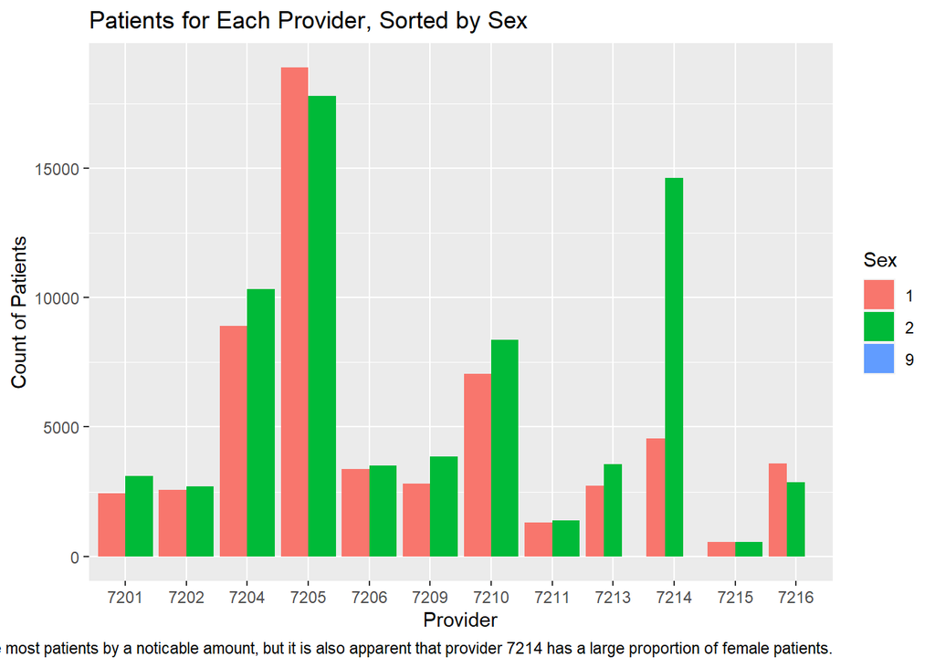

```r
#plot 1
df %>% ggplot() + geom_bar(mapping=aes(x=provider, fill=sex), position = 'dodge') +
  labs(x='Provider',
       y='Count of Patients',
       fill = 'Sex',
       title = 'Patients for Each Provider, Sorted by Sex',
       caption = 'Pink bars indicate males, and green bars indicate females. Provider 7205 has the most patients by a noticable amount, but it is also apparent that provider 7214 has a large proportion of female patients.')
```

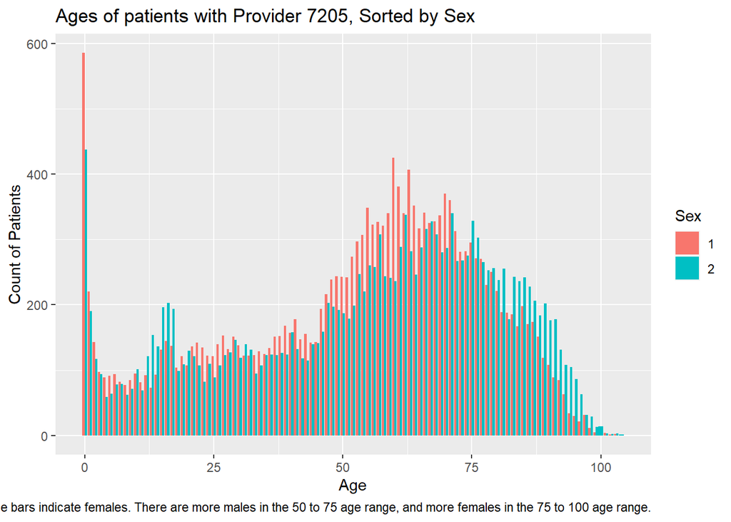

```r
#plot 2
df %>%
  filter(provider == '7205') %>%
  ggplot() + geom_bar(mapping=aes(x=age, fill=sex), position = 'dodge') +
  labs(x='Age',
       y='Count of Patients',
       fill = 'Sex',
       title = 'Ages of patients with Provider 7205, Sorted by Sex',
       caption = 'Pink bars indicate males, and blue bars indicate females. There are more males in the 50 to 75 age range, and more females in the 75 to 100 age range.')
```

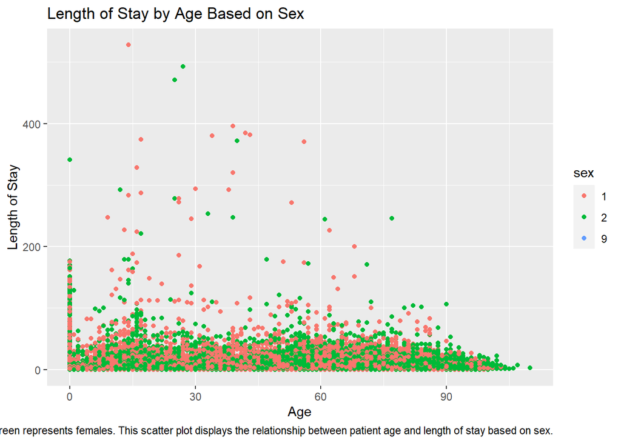

```r
#plot 3
df %>%
  ggplot()+
  geom_point(aes(x=age, y=los, color = sex))+
  labs(x='Age',
       y='Length of Stay',
       title='Length of Stay by Age Based on Sex',
       caption='Pink represents males, green represents females. This scatter plot displays the relationship between patient age and length of stay based on sex.')
```

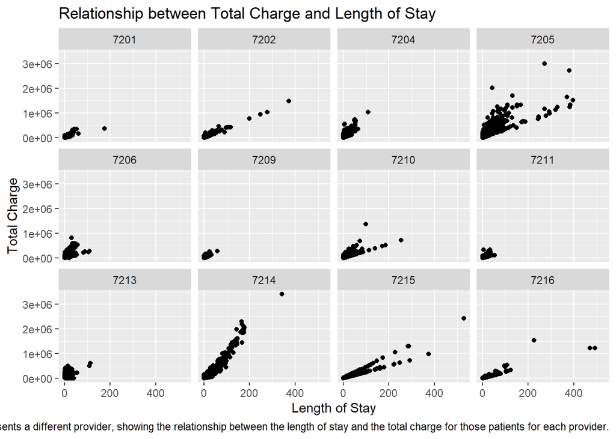

```r
#plot 4
df %>%
  ggplot()+
  geom_point(mapping = aes(x = los, y = tot))+
  facet_wrap(~provider)+
  labs(x='Length of Stay',
       y='Total Charge',
       title='Relationship between Total Charge and Length of Stay',
       caption='Each plot represents a different provider, showing the relationship between the length of stay and the total charge for those patients for each provider.')
```